# My Movies

João Neto

April 2021

This table includes movies I think show an above than average quality in either plot, main themes and overall cinematography. This list represents around one third of all the movies I’ve seen and is, obviously, quite subjective :-)

|  | Title | Year | Decade | Country | Genre | Time | Rate | Imdb | Votes | Director |
| --- | --- | --- | --- | --- | --- | --- | --- | --- | --- | --- |
| 1 | Alone | 2020 | 2020s | USA | Thriller | 98 | 7.75 | 6.2 | 7305 | John Hyams |
| 2 | Mank | 2020 | 2020s | USA | Drama | 131 | 7.75 | 7.1 | 33212 | David Fincher |
| 3 | Soul | 2020 | 2020s | USA | Comedy | 90 | 8.25 | 8.1 | 141337 | Pete Docter |
| 4 | Tenet | 2020 | 2020s | USA | Thriller | 150 | 7.5 | 7.5 | 272119 | Christopher Nolan |
| 5 | The Invisible Man | 2020 | 2020s | USA | Thriller | 124 | 7.5 | 7.1 | 163231 | Leigh Whannell |
| 6 | His House | 2020 | 2020s | UK | Horror | 93 | 7.5 | 6.5 | 22172 | Remi Weekes |
| 7 | Mangrove | 2020 | 2020s | UK | Historical | 127 | 9 | 8.1 | 3349 | Steve McQueen |
| 8 | The Swordsman | 2020 | 2020s | South Korea | Action | 100 | 7.25 | 6.7 | 1105 | Jae-Hoon Choi |
| 9 | Nomadland | 2020 | 2020s | USA | Drama | 108 | 7.25 | 7.6 | 28297 | Chloé Zhao |
| 10 | Us | 2019 | 2010s | USA | Horror | 116 | 7 | 6.9 | 207977 | Jordan Peele |

[output cut: 876 more lines]

## Number of Selected Movies per Year

Showing movies with a minimal rating of 7. The list of movies I wanted to see from 1970-2019 is complete.

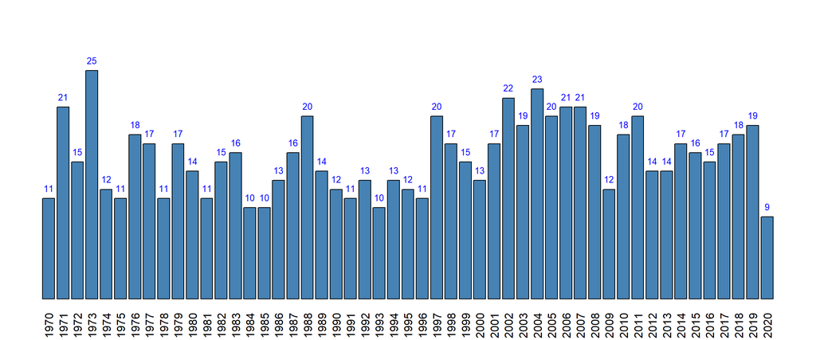

There are hundreds to see from the 1950s and 1960s, and these are the respective wish-lists:

- wishlist from the 1950s
- wishlist from the 1960s

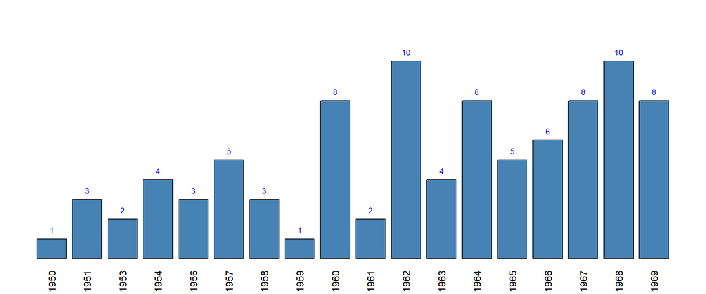

## Number of Selected Movies per Decade

Again using the same filter as above:

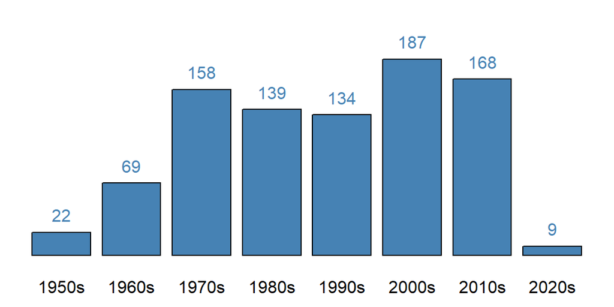

## Movie quality per Decade

Let’s see how many very good films (rating at least 8) each decade produced,

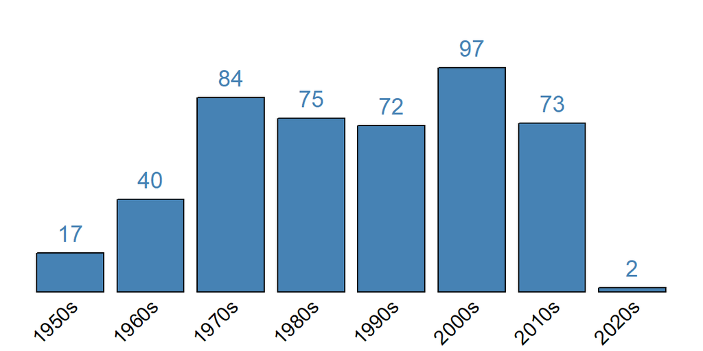

And how many great films (rating at least 9) each decade produced,

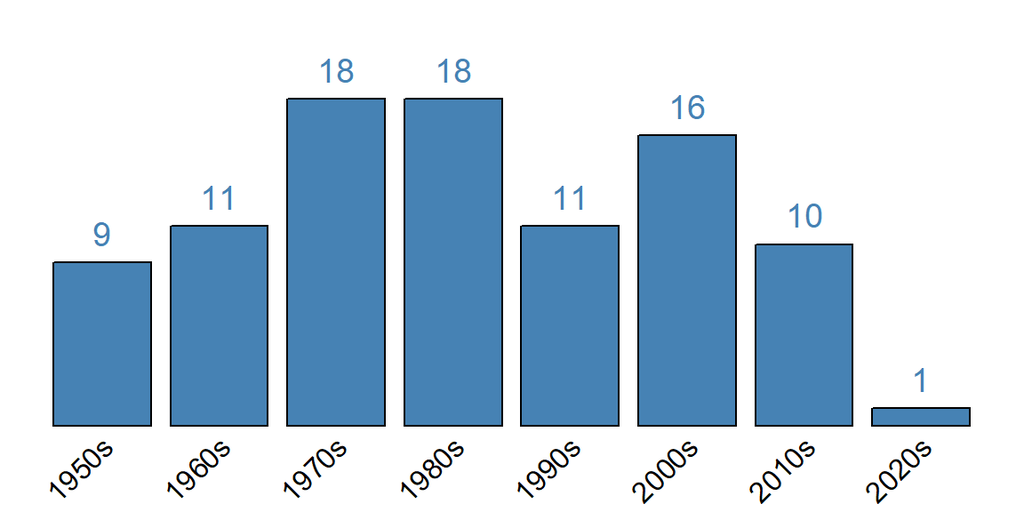

And masterpieces (rating of at least 9.5) per decade,

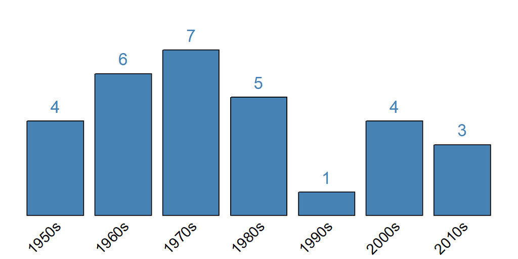

The next plot shows how different rating ranges are represented by decade,

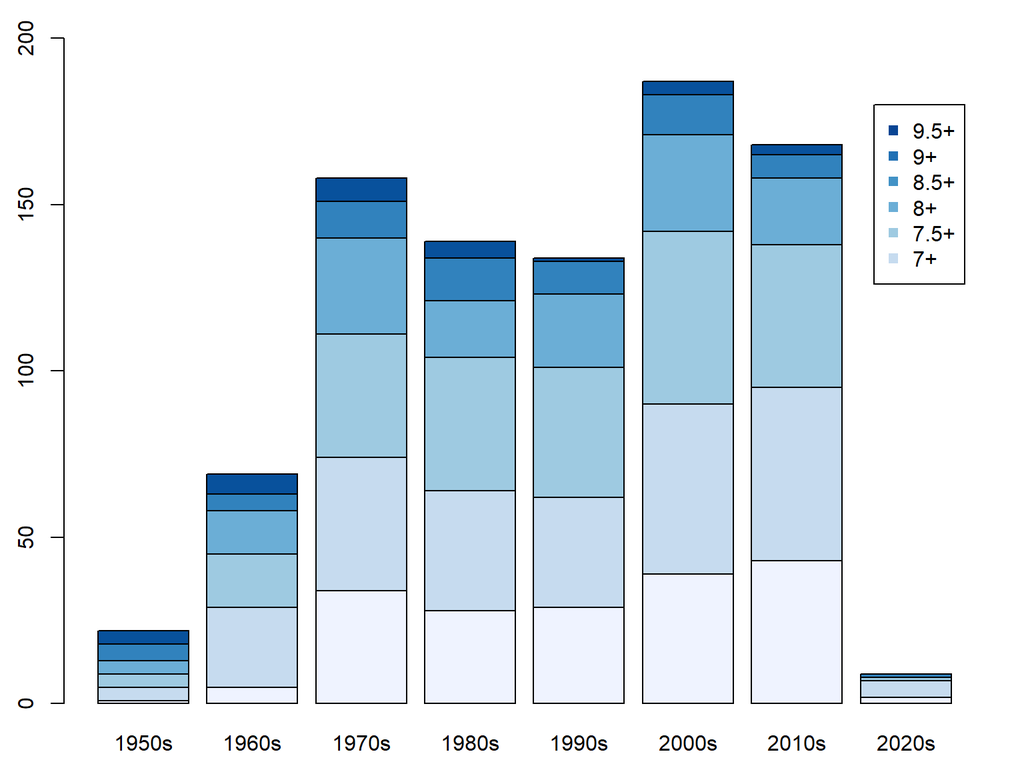

## Movies per Directors

Let’s check directors with multiple movies in the list,

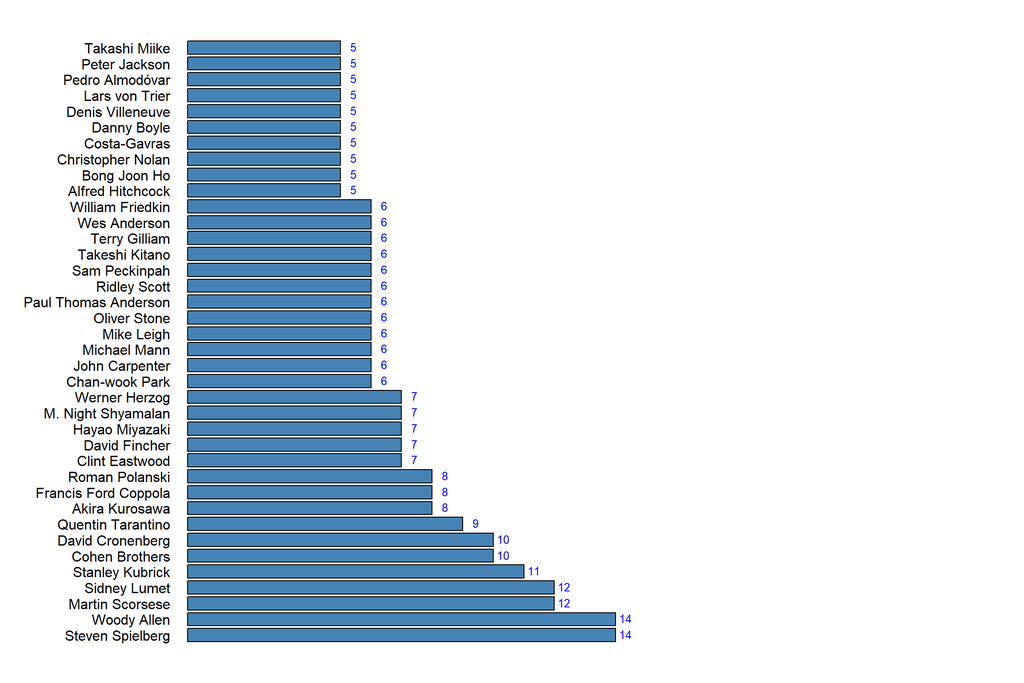

Directors with movies with a rating of at least 8.5,

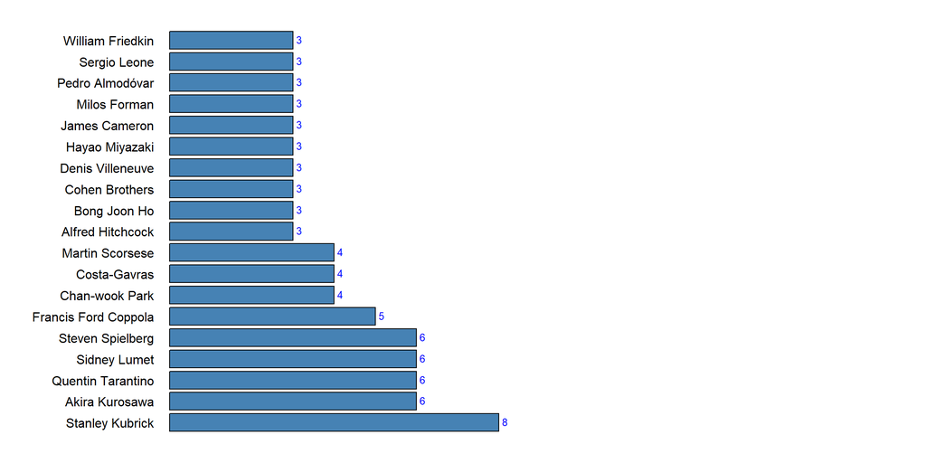

And finally who made the masterpieces (>=9.5),

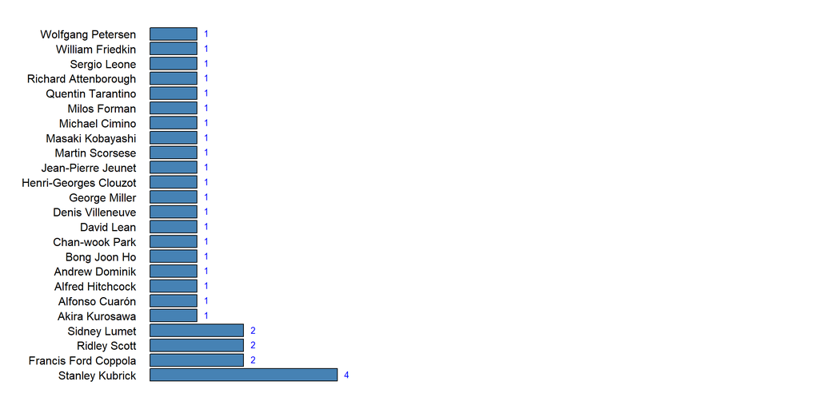

## Movies per Genre

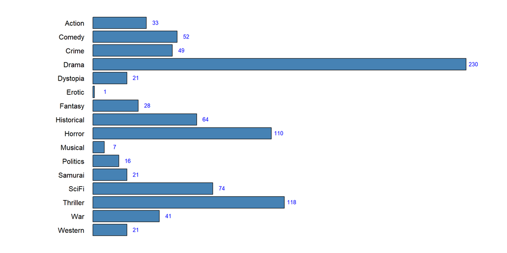

## Movies per Country

Most movies I see are from Hollywood, but let’s check how others countries are represented:

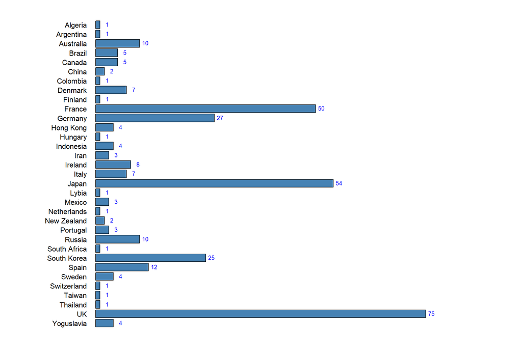